# 4,222 Introduction to Programming

Lecture 2: Getting Started

Dr. Franziska Bender, Dr. Aurélien Sallin

2026-02-20

## Goals for today

In the next 60 minutes, we will learn the basics together:

- learn what a **terminal** is and why we use it
- set up an efficient (and professional) programming **environment** with an IDE
- install **Python** and understand environments
- prepare everything needed for the next lectures

## Vision

Tooling: all the tools you need to work efficiently and in flow!

# Using a terminal

## What is a terminal?

The terminal is a text-based interface that allows you to interact directly with your computer/operating system by typing commands.

#### Alternative names:

“terminal”, “command line”, “shell”, “command prompt”

#### Some terminology:

- Terminal: the window where you type commands and see output
- Shell: the program that interprets your commands (e.g. bash, zsh, PowerShell)

###### You don’t need to worry about the difference at the beginning.

## Why use a terminal

Almost everything you can do with a graphical interface can also be done from the terminal.

#### The terminal is often:

- faster for repetitive tasks
- more precise and reproducible
- easier to automate
- available on almost every system

Because of this, terminals are widely used in programming, data science, and research workflows.

## Opening a terminal

### macOS

**How to open:**

- Press Cmd + Space
- Type “Terminal”
- Press Enter

### Windows

**How to open:**

- Open the Start menu
- Search for “PowerShell” or  
  “Windows Terminal”

#### On Windows, you may see different terminals:

- **Command Prompt (CMD)**: lightweight, text-based, older (early days of Windows), very basic
- **PowerShell**: modern, powerful, widely used, CMD on steroids
- **Windows Terminal**: a modern app that can host both

For this course: Use PowerShell or Windows Terminal.

## Opening your terminal

[figure not shown]

When you first open Terminal you typically are placed in your **home directory**. So let’s start looking and moving around.

## On files, paths, and shortcuts

With the terminal, you access and work with **files**. A file is a container of data (remember from Data Handling: `0`s and `1`s).

- Files have **extensions** (.txt, .csv, .pdf)
- Files live inside **directories** (folders)
- Every file has a unique location called a **path**

## On files, paths, and shortcuts

To access files, their location must be given with **paths**. Paths describe where a file is located.

##### Absolute path:

- starts from the root of the file system
- example: `C:/Users/Bilbo/Documents/TheRedBookofWestmarch.txt`

##### Relative path:

- starts from your current working directory
- example: `Documents/TheRedBookofWestmarch.txt`

## On files, paths, and shortcuts

From the terminal, you can use shortcuts instead of absolute paths.

##### Useful path shortcuts:

`.` current directory

`..` parent directory

`~` your home directory

#### Examples:

- file in the parent directory: `../file.txt`
- your Documents folder: `~/Documents`

## Main terminal commands

As said, when you first open Terminal you typically are placed in your **home directory**.

##### Main commands:

- Check your current directory: `pwd` (**p**rint **w**orking **d**irectory)
- List the files in the current directory: `ls` (macOS, Linux) or `dir` (Windows)
- Move into and out of the directory: `cd dir` or `cd ..` (**c**hange **d**irectory)
- Running `cd` without arguments takes you to `~`

##### Tips:

- Use Tab for auto-completion
- Use arrow keys to browse command history
- Use clear (macOS/Linux) or Ctrl+L to clear the screen

## Working with files in a terminal

| Command | Description |
| --- | --- |
| `mkdir data` | Create/**M**a**k**e a **dir**ectory called “data” |
| `touch hello.txt` | Create an empty text file named “hello” |
| `rm hello.txt` | Delete a file (Careful! Can’t be undone!) |
| `cat hello.txt` | Print contents of a file |
| `nano hello.txt` | Edit a file |
| `cp hello.txt hello_copy.txt` | Copy a file (`cp <source> <target>`) |
| `mv hello.txt goodbye.txt` | Move a file (`mv <source> <target>`) |

Look at bradtraversy’s [Common Terminal Commands](https://gist.github.com/bradtraversy/cc180de0edee05075a6139e42d5f28ce)

## Naming Conventions: 🐍, 🐫 or 🍢

- **Do not use spaces** in folder or file names! Never.
- Avoid special characters (remember Data Handling and encoding nightmares).
- Make sure to **not switch styles** within a project.
- Go for `camelCase`, `snake_case` or `kebab-case`.

#### Examples:

- snake_case: `my_file_name.py`
- camelCase: `myFileName.py`
- kebab-case: `my-file-name.py`

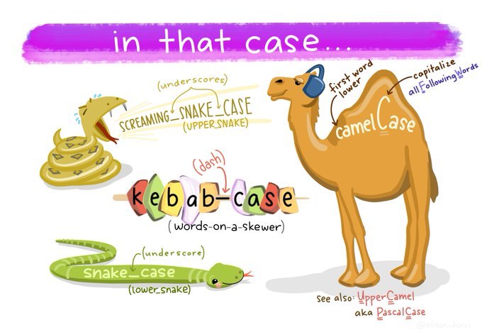

## Naming Conventions: 🐍, 🐫 or 🍢

[figure not shown]

Following an established convention will not make you look like a complete novice. 😎🆒

# On IDEs

## What is an IDE?

An **IDE** (**I**ntegrated **D**evelopment **E**nvironment) is a tool designed to help you write, run, and manage code efficiently.

Compared to a basic text editor, an IDE typically provides:

- syntax highlighting
- code completion and suggestions
- error detection
- integrated terminal
- debugging tools
- version control integration (e.g. Git)

These features reduce errors and make programming more structured and productive.

**Examples**: VSCode, Pycharm, RStudio, Posit

## Visual Studio Code

Visual Studio Code (VS Code) is a lightweight but powerful code editor that behaves like a full IDE through **extensions**.

- free and open source
- available on Windows, macOS, and Linux
- widely used in academia and industry
- well suited for Python, R, and many other languages
- very versatile and flexible!
- integrated terminal
- strong Python support
- extensions for Git, notebooks, linters, and formatters
- integrated Copilot!
- syncs to all machines with a GitHub account

[figure not shown]

## First setup (exercise session today)

- Install VS Code
- Open it once
- Install the “Data Science” profile (File > Preferences > Profiles)
- Extensions to install:
  - Python (Microsoft): For linting, IntelliSense, debugging, and testing
  - Pylance (Microsoft): type checking, code navigation, autocompletion
  - Ruff: for better linting, import sorting
  - Jupyter: runs notebooks directly in VS Code.

We will build on this setup throughout the course.

*Linting is the process of analyzing code to identify potential errors, style violations, and code quality issues before running the program. Using linting tools can help detect problems such as syntax errors, unused variables, and code that doesn’t conform to style guidelines

# Python

## Why python?

Python is a good first (and second…) programming language.

- easy to read and write
- widely used in data science, economics, research, web development, automation, and AI
- flexible enough for small scripts and large projects

#### Python or R?

“**It simply does not matter**. If you stick around in data science long enough, you will eventually get in touch with both languages and, in turn, learn both. There is a huge overlap of what you can do with either of those languages. The point is, if you just start doing analytics using a programming language, both languages are guaranteed to carry you a long way. There is no way to tell for sure which one will be the more dominant language 10 years from now, or whether both will be around holding their ground the way they do now.” Matthias Bannert, “Research Software Engineering”

## Environments in Python and R

A first striking difference (and a source of lots of sweat) between R and Python is dependency management.

#### In R:

- strong(er) standards (CRAN)
- more backward compatibility

#### In Python:

- Python relies heavily on project-specific environments
- Managing dependencies is essential
- “Wild West”: many packages, many versions
- environments are critical to avoid conflicts

## Virtual environment

A **virtual environment** is an isolated Python setup for a project.

- install project-specific packages and python version for a specific project without affecting other projects
- use different versions across projects
- avoid conflicts and broken setups, minimizes the risk of bad surprises

A **project** is simply a folder that contains your code, its configuration, and its dependencies.

## Virtual Environment Manager: `uv`

`uv` is a modern, fast Python package manager that simplifies working with environment:

- manages virtual environments automatically
- installs packages very fast
- works consistently across systems
- uses modern project standards

(Replaces pip, pip-tools, and virtualenv.)

## Virtual Environment Manager: `uv`

With uv, each project has:

- its own environment
- a clear list of dependencies
- reproducible setup

This is how professional Python projects are structured.

## Getting started using `uv`

```python
# Initialize a new project with its own environment
uv init my_project
cd my_project

# Add dependencies (creates/updates pyproject.toml)
uv add rich pandas

# Run code (automatically uses the project's venv)
uv run main.py
```

Project based on the pyproject.toml.

## Python in the shell or in a .py file

You can use Python in two ways:

- interactively in the terminal
- by writing code in .py files

We will mainly work with .py files inside projects.

```python
print('Hello World')
```

```
Hello World
```

```python
print(2 + 3)             # addition(+)
```

```
5
```

```python
print(3 - 1)             # subtraction(-)
```

```
2
```

## Coming from R

If you know R (which you do…), Python will feel familiar, but not identical.

#### Key differences to keep in mind:

- indentation is part of the language
- indexing starts at 0
- Python prefers **explicit, readable code**

We will revisit these ideas throughout the course.

## Indentation

In Python, indentation defines the structure of your code.

Blocks of code are created by indentation, not by curly braces {} like in many other languages.

- indentation is mandatory
- inconsistent indentation will break your code

```python
if x > 0:
    print("positive")
    print("still inside the block")

print("outside the block")
```

## Counting starts at 0

In Python, many things start counting at 0 (**zero-based indexing**).

#### Example:

- the first element has index 0
- the second element has index 1

Common in programming, even if it feels unintuitive at first.

## For next time

- install Git

We will start using version control from the next lecture.

## References:

- Matthias Bannert, [Research Software Engineering](https://rse-book.github.io/interaction.html)